# 568CCourseProj

Lakshmi

1/22/2020

## DATA SCIENCE QUESTION

The cost of a college education is skyrocketing. It’s no surprise that student loans now make up the largest chunk of U.S. non-housing debt. If we know how much to save for college education in the future, we will have the flexibility of making financial adjustments without compromising on the quality of life and make more informed financial decisions. With this motto, I would like to answer the following questions through modelling:  What would be the tuition fees for any 4 Year public university program in the future?  Which factor influences the education cost the most – Debt_GDP or Consumer Price Index?

## INPUT AND OUTPUT VARIABLES

 Output variable: Average Tuition and Fees and Room and Board (Enrollment-Weighted) in Current Dollars from 1986-2019 for any 4 Year Public University degree.  Input variables: • Consumer price index (CPI): The Consumer Price Index (CPI) is a measure that examines the average of prices of a basket of consumer goods and services, such as transportation, food, and medical care. It is calculated by taking price changes for each item in the predetermined basket of goods and averaging them. Changes in the CPI are used to assess price changes associated with the cost of living; the CPI is one of the most frequently used statistics for identifying periods of inflation or deflation. • Debt-to-GDP ratio: A metric comparing a country’s public debt to its gross domestic product (GDP). By comparing what a country owes with what it produces, the debt-to-GDP ratio reliably indicates that particular country’s ability to pay back its debts. Often expressed as a percentage, this ratio can also be interpreted as the number of Years needed to pay back debt, if GDP is dedicated entirely to debt repayment.

## DATA SOURCE

Bureau of Labor Statistics (Consumer Price Index, All Urban Consumers).

## CLEANING DATA AND FEATURE ENGINEERING

 Read the education costs data set, clean the data by converting literal NA’s and hyphens to 0’s, and scrapping off the irrelevant texts.  Combine tuition fees and board room fees into total costs for public2Year, public4Year and privatenonprofit4Year courses.  Convert all the costs into numeric values  Get the distribution of costs using histogram and bar plot  Get the log –transformed distribution of costs using histogram  Calculate the mean and median costs of public2Year, public4Year and private4Year  Read the inflation and Debt_GDP datasets  Merge them with education costs dataset for the Years 1986-2019  Rename the columns appropriately.

```r
#1) Read the worksheet number 5, skip 1st 11 rows
data <- readxl::read_xlsx('college_pricing.xlsx',sheet = 5, skip=11)

#2) Remove the last 3 lines from the dataset which are simplyextra texts
data <- head(data,-3)

#3)look for NA's
for(i in 1:dim(data)[2])
{
  print(paste(names(data)[i], length(which(is.na(data[,i])))))
}
```

```
## [1] "In Current Dollars 0"
## [1] "1986 0"
## [1] "1987 0"
## [1] "1988 0"
## [1] "1989 0"
## [1] "1990 0"
## [1] "1991 0"
## [1] "1992 0"
## [1] "1993 0"
## [1] "1994 0"
## [1] "1995 0"
## [1] "1996 0"
## [1] "1997 0"
## [1] "1998 0"
## [1] "1999 0"
```

[output cut: 22 more lines]

```r
#4) Get each of row's data and remove 1st column as these are row headers
data_row1 <- data[1,-1]
data_row2 <- data[2,-1]
data_row3 <- data[3,-1]
data_row8 <- data[8,-1]
data_row9 <- data[9,-1]

#5) Get the length of the dataset from above step
length(data_row1)
```

```
## [1] 36
```

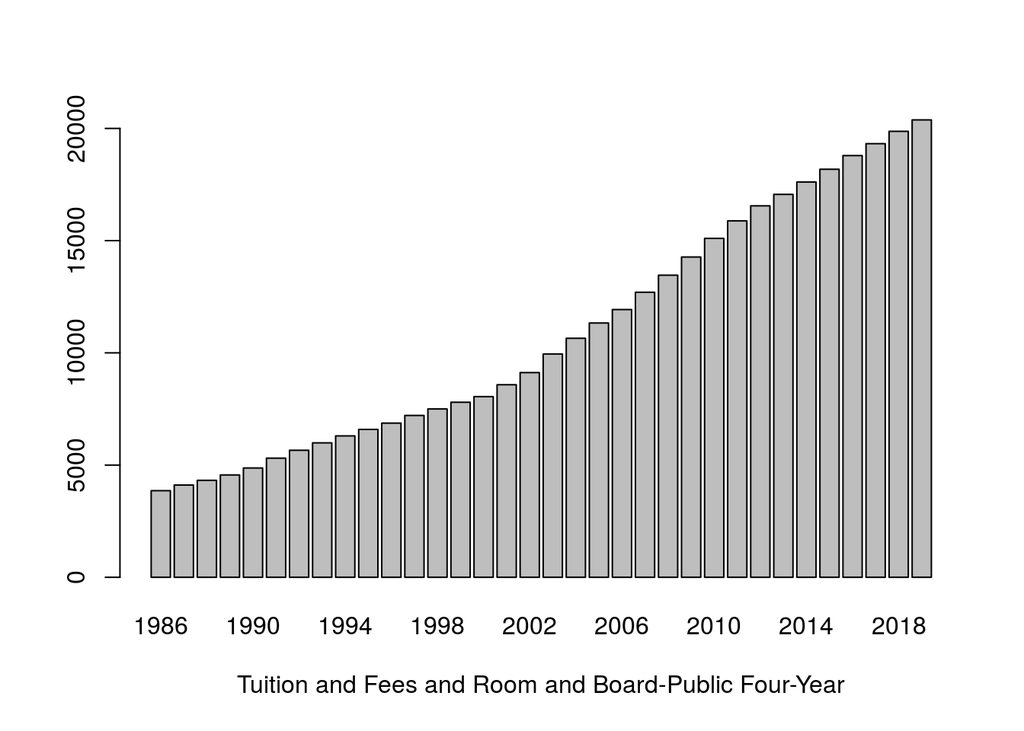

```r
#6) Remove the last 2 values from the obtained row vectors in step 4 and convert all the values into #numeric values
Tuition_Public_Two_Year <- as.numeric(data_row1[c(-35,-36)])
Tuition_Public_Four_Year <- as.numeric(data_row2[c(-35,-36)])
Tuition_Private_Nonprofit_Four_Year <- as.numeric(data_row3[c(-35,-36)])
Tuition_Room_Board_Public_Four_Year <- as.numeric(data_row8[c(-35,-36)])
Tuition_Room_Board_Private_Nonprofit_Four_Year <- as.numeric(data_row9[c(-35,-36)])

#7) All entries from the row vectors in step 4 are converted to numeric
Tuition_Public_Two_Year_all <- as.numeric(data_row1)

#8) transpose the data df in order to get the row names or Years using rownames
data_transpose <- t(data)

#9) Remove the 1st and last 2 values from rownames(data_transpose) to get only the Years
Year <- rownames(data_transpose)[c(-1,-36)][-35]

#10) Look for values '—' and convert them into 0. Format row 4 and row 7 as numeric 0s
data[data == '—'] <- 0
data_row7 <- data[7,-1]
data_row4 <- data[4,-1]
Room_Board_Public_Two_Year <- as.numeric(data_row4)
Tuition_Room_Board_Public_Two_Year <- as.numeric(data_row7)

#11)Update the 7th row count as sum of  row 1 and row 4
Tuition_Room_Board_Public_Two_Year <- Tuition_Public_Two_Year_all + Room_Board_Public_Two_Year
Tuition_Room_Board_Public_Two_Year <- as.numeric(Tuition_Room_Board_Public_Two_Year[c(-35,-36)])
data[7,-1] <- Tuition_Public_Two_Year_all + Room_Board_Public_Two_Year

#12a) Plot the barplots for the datasets in step 6  where x axis= Years
barplot(Tuition_Room_Board_Public_Four_Year, names.arg=Year, xlab='Tuition and Fees and Room and Board-Public Four-Year')
```

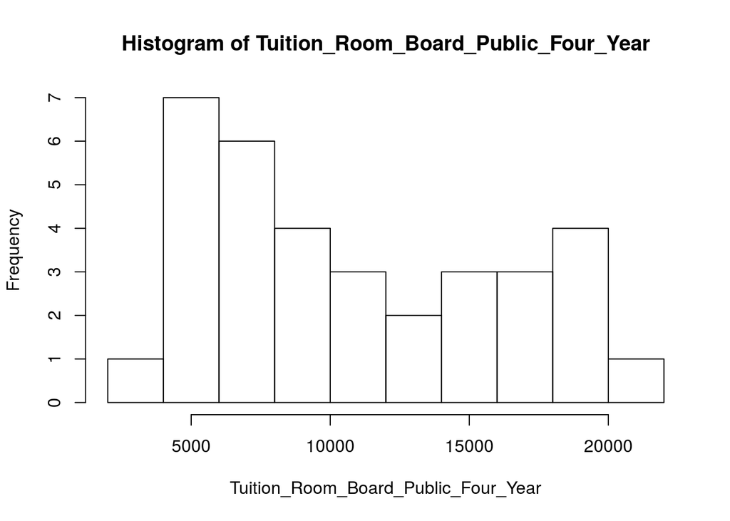

```r
#12b) Histogram
hist(Tuition_Room_Board_Public_Four_Year)
```